# projektBigFive

Homo SAPiens

12/16/2021

#ucitavanje paketa Učitajmo potrebne pakete

```r
library(dplyr)
```

#Učitavanje podataka

Učitajmo podatke iz .csv file-a

```r
bigFiveData = read.csv("../big_five_scores.csv")
dim(bigFiveData)
```

```
## [1] 307313      9
```

Podaci se sastoje od 307 313 testiranih ljudi i 9 varijabli koje promatramo.

Popis varijabli koje promatramo:

```r
names(bigFiveData)
```

```
## [1] "case_id"                 "country"
## [3] "age"                     "sex"
## [5] "agreeable_score"         "extraversion_score"
## [7] "openness_score"          "conscientiousness_score"
## [9] "neuroticism_score"
```

Za testirane sudionike u tablici su navedeni njihovi podaci (godina, zemlja, spol) te 5 faktora koje promtramo(ekstraverzija, ugodnost, savjesnost, neuroticizam i otvorenost)

Možemo promotriti ponašanje varijabli.

```r
summary(bigFiveData)
```

```
##     case_id         country               age             sex
##  Min.   :     1   Length:307313      Min.   :10.00   Min.   :1.000
##  1st Qu.: 83653   Class :character   1st Qu.:18.00   1st Qu.:1.000
##  Median :166286   Mode  :character   Median :22.00   Median :2.000
##  Mean   :166682                      Mean   :25.19   Mean   :1.602
##  3rd Qu.:249627                      3rd Qu.:29.00   3rd Qu.:2.000
##  Max.   :334161                      Max.   :99.00   Max.   :2.000
##  agreeable_score  extraversion_score openness_score   conscientiousness_score
##  Min.   :0.2000   Min.   :0.2000     Min.   :0.2533   Min.   :0.2067
##  1st Qu.:0.6400   1st Qu.:0.6000     1st Qu.:0.6733   1st Qu.:0.6300
##  Median :0.7033   Median :0.6800     Median :0.7367   Median :0.7067
##  Mean   :0.6968   Mean   :0.6723     Mean   :0.7339   Mean   :0.7020
##  3rd Qu.:0.7633   3rd Qu.:0.7500     3rd Qu.:0.7967   3rd Qu.:0.7767
##  Max.   :1.0000   Max.   :0.9933     Max.   :0.9967   Max.   :1.0000
##  neuroticism_score
##  Min.   :0.1967
##  1st Qu.:0.4867
##  Median :0.5700
##  Mean   :0.5744
##  3rd Qu.:0.6600
##  Max.   :0.9967
```

```r
sapply(bigFiveData, class)
```

```
##                 case_id                 country                     age
##               "integer"             "character"               "integer"
##                     sex         agreeable_score      extraversion_score
##               "integer"               "numeric"               "numeric"
##          openness_score conscientiousness_score       neuroticism_score
##               "numeric"               "numeric"               "numeric"
```

Vidimo iz prioloženog tip podataka danih varijabli. Zemlja je zadana stringom, dok su ostale varijable brojčane(int ili numeric). Svi faktori koje promatramo su numeric tipa i imaju vrijednost od 0 do 1.

Sada gledamo postoje li u našem skupu podataka nedostajuće vrijednosti jer one mogu poremetiti rezultate testa. Promatramo sve varijable i brojimo koliko je NA vrijednosti ako ih ima.

```r
for (col_name in names(bigFiveData)){
  if (sum(is.na(bigFiveData[,col_name])) > 0){
    cat('Ukupno nedostajućih vrijednosti za varijablu ',col_name, ': ', sum(is.na(bigFiveData[,col_name])),'\n')
  }
}
```

Po rezultatima vidimo da nemamo NA vrijednosti(neodostajućih) ni u jednoj varijabli. Podaci su uredni.

Promotrimo sada kako izgledaju varijable koje dobijemo kao informaciju od ispitanika (godine, zemlja, spol)

Prov ćemo gledati godine jer je to numerička:

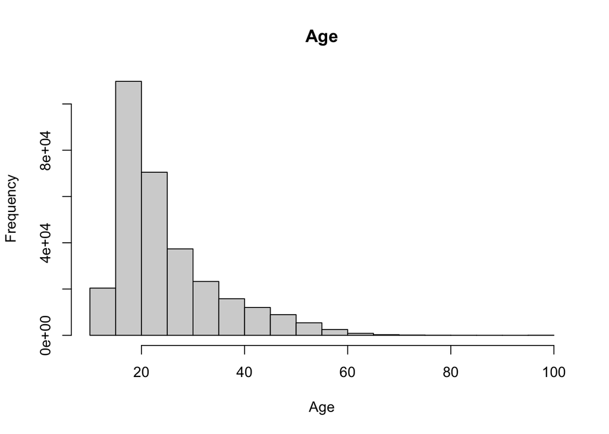

```r
hist(bigFiveData$age,main='Age', xlab='Age', ylab='Frequency')
```

Vidimo da rezultat nije normalne dristirbucije, pa ćemo pokušati log transformacijom približiti normalnoj.

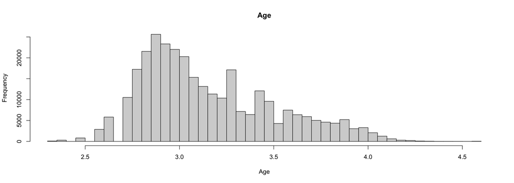

```r
hist(log(bigFiveData$age),main='Age',xlab='Age',ylab='Frequency', breaks=50)
```

Vidimo da smo se uspjeli približiti normalnoj razdiobi.

Sad ćemo pogledati kategorijske varijable (spol i država)

```r
#broj Muskih i Zenskih ispitanika
print("Podjela na M i Z: ")
```

```
## [1] "Podjela na M i Z: "
```

```r
table(bigFiveData$sex)
```

```
##
##      1      2
## 122164 185149
```

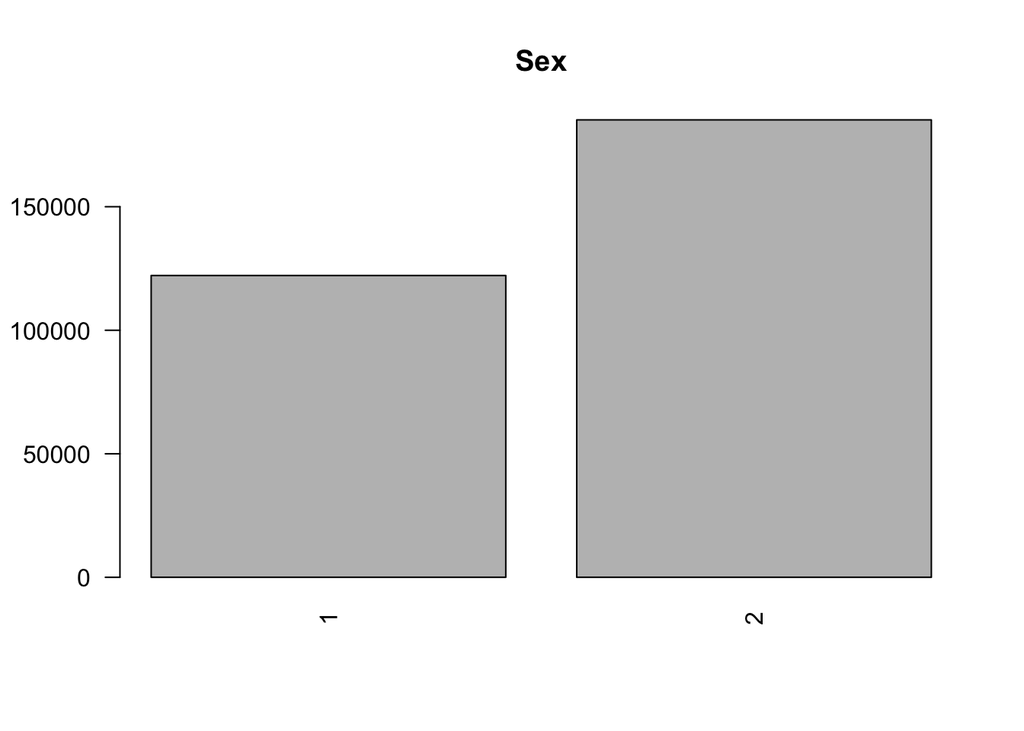

```r
barplot(table(bigFiveData$sex), las=2, main='Sex')
```

```r
table(bigFiveData$country)
```

```
##
##            Afghanista    Albania    Algeria    Andorra     Angola   Anguilla
##        172        624        527        360        167         97         83
## Antarctica    Antigua Arabian Gu  Argentina    Armenia      Aruba  Australia
##         74         36         32        235         40         23      10400
##    Austria Azerbaijan    Bahamas    Bahrain Bangladesh   Barbados    Belarus
##        223         47         83         42         63         57         33
##    Belgium     Belize      Benin    Bermuda     Bhutan    Bolivia     Borneo
##        663         26          7         35         13         33         11
## Bosnia Her   Botswana Bouvet Isl     Brazil British In British Vi     Brunei
##         77         10          3        661         21         60         22
##   Bulgaria Burkina Fa      Burma Burma(Myan    Burundi   Cambodia   Cameroon
##        176          6          6         18          7         19         26
##     Canada Cape Verde Cayman Isl Central Af       Chad      Chile      China
##      21798         66         63         19          8         81        915
##  Christmas Cocos (Kee   Columbia    Comoros      Congo Cook Islan Costa Rica
##          3          4        209          4          6          5         75
##    Croatia       Cuba     Cyprus Czech Repu    Denmark   Djibouti   Dominica
##        307         76         77        108        614          5         10
##  Dominican East Timor    Ecuador      Egypt El Salvado Equatorial    Eritrea
##         75          2         56        286         47          1          4
##    Estonia   Ethiopia Faeroe Isl Falkland I       Fiji    Finland     France
##        189         27          8          4         17       1853        854
## French Gui French Pol      Gabon     Gambia    Georgia    Germany      Ghana
##          7          8          4          5         30       1167         32
##  Gibraltar     Greece  Greenland    Grenada Guadeloupe       Guam  Guatemala
##         17        653          7         11          3         36         44
##     Guinea Guinea-Bis     Guyana      Haiti   Honduras  Hong Kong    Hungary
##          2          1         21         31         36        750        129
##    Iceland      India  Indonesia       Iran       Iraq    Ireland     Israel
##        159       2841        257        117         25       2102        515
##      Italy Ivory Coas    Jamaica      Japan Johnston I     Jordan Kazakhstan
##        454         10        129        398          3         82         16
##      Kenya     Kuwait  Kyrgystan Lao P.Dem.     Latvia    Lebanon    Lesotho
##         90         52          6          5        190        159          4
##    Liberia Libyan Ara Liechtenst  Lithuania Luxembourg      Macau  Macedonia
##          6          3          1        118         26         19         28
## Madagascar     Malawi   Malaysia   Maldives       Mali      Malta Marshall I
##          4          3        911         12          2        108          3
## Martinique Mauritania  Mauritius     Mexico Micronesia    Moldova     Monaco
```

[output cut: 14 more lines]

```
##          7          5       2450         93        178          4          8
## South Afri South Kore      Spain  Sri Lanka   St Lucia St Vincent      Sudan
##        927        446        417         62         15          8         12
##   Suriname Svalbard &  Swaziland     Sweden Switzerlan      Syria     Taiwan
##          4          2          4       1352        217         24        248
##   Tanzania   Thailand       Togo    Tokelau      Tonga Trinidad a    Tunisia
##         14       2059          8          2          4        158         12
##     Turkey Turkmenist  Turks and     Tuvalu     Uganda         UK    Ukraine
##        396          7         21         11        120      16489        179
## United Ara    Uruguay        USA Uzbekistan    Vanuatu    Vatican Vatican Ci
##        196         45     212625         20          7          2          6
##  Venezuela    Vietnam Virgin Isl   W. Samoa Wake Islan Wallis and Western Sa
##        126        127         14          1          3          2          1
##      Yemen Yugoslavia      Zaire     Zambia   Zimbabwe
##          6        178          2         10         55
```

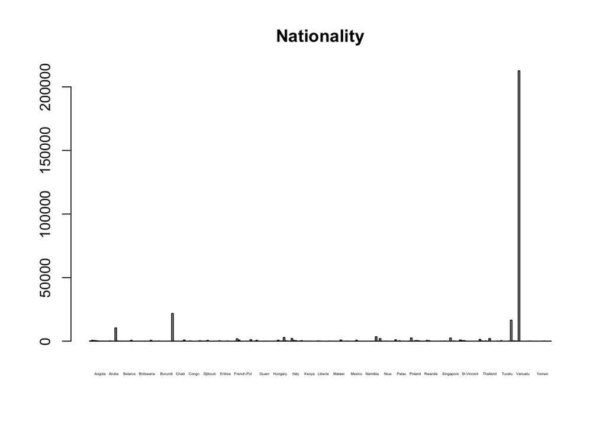

```r
barplot(table(bigFiveData$country),cex.names = .25, main="Nationality")
```

Sada kad smo pregledali podatke koje imamo, možemo krenuti na testiranje hipoteza.

#prvi test

1. TEST Ako grupiramo ispitanike na mlade i stare, mozemo li vidjeti znacajnu razliku u otvorenosti prema novim iskustvima?

pretpostavka:

H0: Mladi su otvoreniji prema iskustvima, nego stari.

H1: Mladi nisu otvoreniji prema iskustvima.

Ovdje ćemo koristiti jendostrani t-test za testiranje.

T-test za prepostavku uzima normalnost podataka, pa prije početka testiranja moramo pokazati normalnost.

Za početak ćemo nacrtati histogram i odokativno vidjeti.

```r
#histogram za mlade/stare!
# prvo cemo uzeti da su mladi <=30 , stari >30
```